# Phy 410 - Hw 10

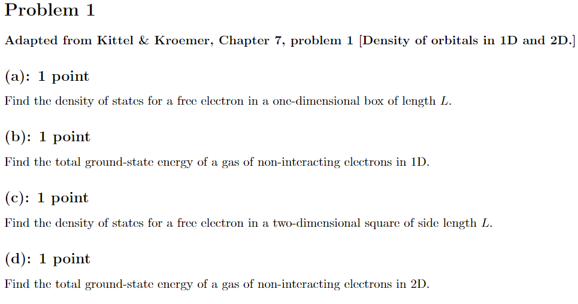

(a) 1D electron energy

$$ \epsilon_n = \frac{\hbar^2}{2M} \left(\frac{\pi n}{L}\right)^2 $$

Where we choose $n$. I believe $n$ is actually the number of particles in the box too (x2 since two per orbital)

$$ N(\epsilon) = \frac{2L}{\pi} \sqrt{\epsilon \frac{2M}{\hbar^2} } \\ = \frac{2L}{\hbar \pi} \sqrt{2M\epsilon} $$ This gives us our density of states $$ \mathcal D(\epsilon) \equiv \frac{dN}{d\epsilon} = \frac{2L}{\hbar \pi} \sqrt{2M\epsilon} \frac{1}{2 \epsilon} \\ = \frac{L}{\hbar \pi} \sqrt{\frac{2M}{\epsilon}} $$

(b) ground state energy. Depends on fermi energy

$$ U_0 = \int_0^{\epsilon_F} \epsilon \mathcal D(\epsilon) d\epsilon \\ = \frac{L}{\hbar \pi} \sqrt{2M} \int_0^{\epsilon_F} \sqrt{\epsilon} d\epsilon = \frac{L}{\hbar \pi} \sqrt{2M} \frac{2 \epsilon_F^{3/2}}{3 } \\ = \frac{2\sqrt{2}}{3}\frac{L}{3\hbar \pi} \sqrt{M\epsilon_F^3} $$

This can be converted back to $N$ using the above equation for $\epsilon_n$ and $N=2n$

(c) 2D. Not so bad, just need to redefine $n$ and $N$.

A 1/4 circle with $n$-radius has

$$ N = 2 \times 1/4 \times \pi n^2 \\ n = \sqrt{\frac{2N}{\pi}} \\ \epsilon_n = \frac{\hbar^2}{2M} \left(\frac{\pi n}{L} \right)^2 = \frac{N \hbar^2 \pi}{ML^2} \\ N = \frac{ML^2\epsilon}{\pi \hbar^2} \\ \frac{\partial N}{\partial \epsilon} = \frac{ML^2}{\pi \hbar^2} $$

(d) Use the same procedure as before to find our ground state

$$ U_0 = \int_0^{\epsilon_F} \epsilon \mathcal D(\epsilon) d\epsilon \\ = \frac{ML^2 \epsilon_F^2}{2\pi \hbar^2} $$

```python
import sympy as sp
from sympy.abc import epsilon, n, N, L, M
hbar, eF = sp.symbols('hbar epsilon_F')

n = sp.sqrt(2*N/sp.pi)
en = hbar**2/(2*M) * (sp.pi*n/L)**2
DOS = sp.solve(sp.Eq(epsilon, en), N)[0]/epsilon

U0 = sp.integrate(epsilon*DOS, (epsilon, 0, eF))
U0
```

$\displaystyle \frac{L^{2} M \epsilon_{F}^{2}}{2 \pi \hbar^{2}}$

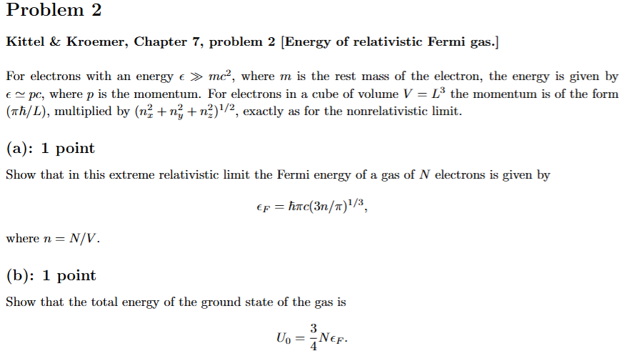

(a) Normally I'd use $c=1$, but we'll leave it in since the ultrarelativistic case is pretty simple.

$$ f = \frac{\pi}{L}n_{xyz} \\ p = \hbar f = \frac{\pi \hbar}{L} n_{xyz} \\ \epsilon = \hbar c f = \hbar c \frac{\pi }{L} n_{xyz} $$

All we need is to find $N$ to get $\epsilon_F$

$$ N = \frac{\pi}{3}n_{xyz}^3 \\ n_{xyz} = \sqrt[3]{\frac{3N}{\pi}} \\ = \sqrt[3]{\frac{3nL^3}{\pi}} \\ $$ Going back to energy, $$ \epsilon = \hbar \pi c \frac{1}{L}\sqrt[3]{\frac{3nL^3}{\pi}} \\ = \hbar \pi c \left(\frac{3n}{\pi}\right)^{1/3} $$

(b) Get the DoF and find $U_0$ (no temp, high velocity)

$$ \left( \frac{\epsilon}{\hbar \pi c} \right)^3 \frac{\pi}{3} = n \\ N = \frac{\pi L^3}{3} \left( \frac{\epsilon}{\hbar \pi c} \right)^3 \\ \frac{dN}{d\epsilon} = \frac{\epsilon^2 \pi L^3}{\left(\hbar \pi c\right)^3} \\ U_0 = \int_0^{\epsilon_F} \frac{\epsilon^3 \pi L^3}{\left(\hbar \pi c\right)^3} d\epsilon = \frac{\epsilon_F^4 \pi L^3}{4\left(\hbar \pi c\right)^3} $$

Oh no! This looks so different. No worries, we just need to convert some $\epsilon$ to $N$.

$$ U_0 = \frac{\epsilon_F}{4} \left( 3\frac{\pi L^3}{3}\left(\frac{\epsilon_F}{\hbar \pi c}\right)^3\right) = \frac{\epsilon_F}{4} (3N) = \frac{3}{4}\epsilon_F N $$

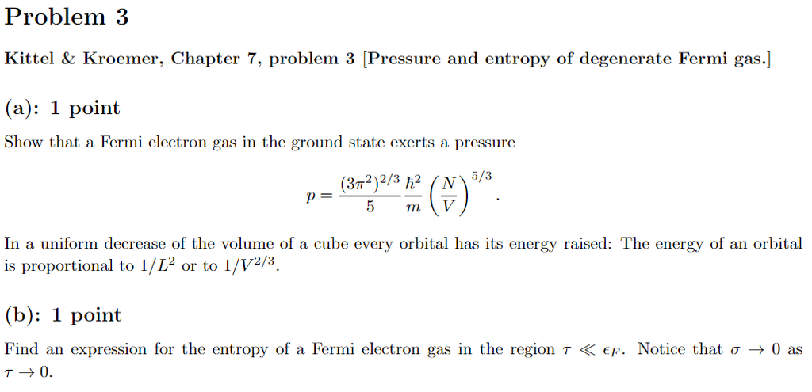

(a) We already did most of the heavy lifting for fermi electron gas. In ground state we have

$$ U_0 = \frac{3}{5} N \epsilon_F \\ \epsilon_F = \frac{\hbar^2}{2m} \left( 3\pi^2 \frac{N}{V} \right)^{2/3} \\ P = -\frac{\partial U}{\partial V} \\ =\frac{\partial}{\partial V}\frac{3 (3\pi^2)^{2/3}}{5} \frac{\hbar^2}{2m} N^{5/3} \frac{1}{V^{2/3}} \\ =\frac{(3\pi^2)^{2/3}}{5} \frac{\hbar^2}{m} \frac{N^{5/3} }{V^{5/3}} $$

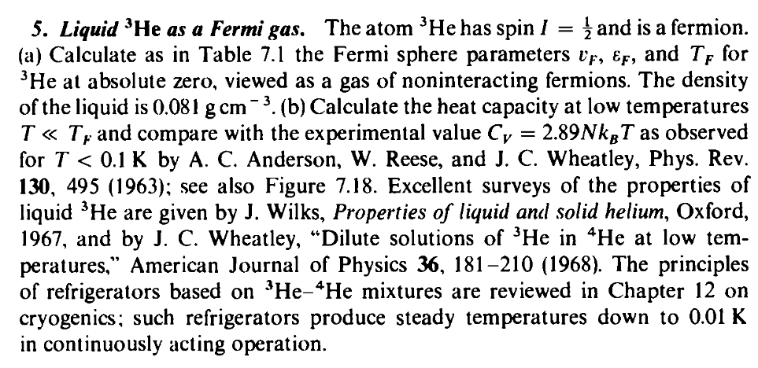

Mass of liquid 3He is 3 amu = $4.98\times 10^{-24}g$

This gives us

$$ \frac{N}{V} = \frac{0.081}{4.98\times 10^{-24}} = 1.63\times 10^{22} $$ Thus we have $$ \epsilon_F = \frac{\hbar^2}{2m} \left(\frac{3\pi^2 N}{V}\right)^{2/3} = 6.86\times 10^{-16} $$ (using erg to make things easier)
This gives us v and T easily $$ v_F = \sqrt{\frac{2\epsilon_F}{M}} = 16.6 m/s \\ T_F = \frac{\epsilon_F}{k_B} = 4.97 K \\ $$

(b) Using (6.38) from the book we have

$$ C_{el} = \frac{1}{2} \pi^2 N k_B \frac{T}{T_F} = 0.99K $$

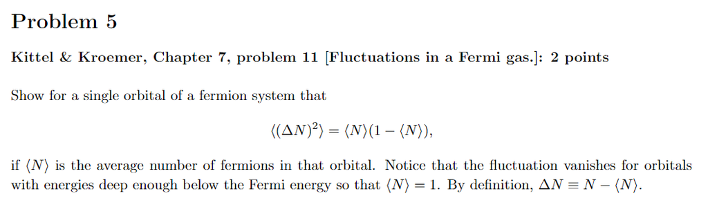

$$ \langle (\Delta N)^2 \rangle = \langle N^2 \rangle - \langle N \rangle^2 $$

A single orbital fermion is either $N=0$ or $N=1$, so $\langle N^2 \rangle = \langle N \rangle$!!!

This is much easier than I thought it would be.

$$ \langle N^2 \rangle - \langle N \rangle^2 = \langle N \rangle - \langle N \rangle^2 = \langle N \rangle \left(1- \langle N \rangle \right) $$ I guess the text at the bottom explains why this result is important

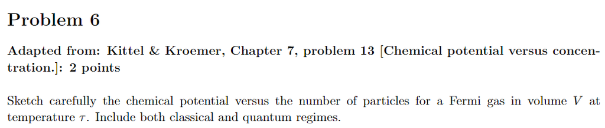

Thank you for easy problems (-me at 4:30pm on Wednesday)

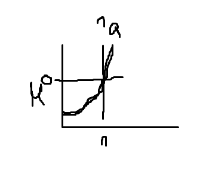